# Chp_13 homework

Probblems:

## 13E1. Add to the following model varying slopes on the predictor x.

yi ∼ Normal(μi, σ) μi = αgroup[i] + βx[i]

[αgroup, βx] ∼ MVNormal([α β ], S)

S = (σα, 0 ` R(σα, 0 0, σβ) 0, σβ)

α ∼ Normal(0, 10) β ∼ Normal(0, 1) σ ∼ HalfCauchy(0, 2) σα ∼ HalfCauchy(0, 2) R ~ LKJcorr(2)

## 13E2. Think up a context in which varying intercepts will be positively correlated with varying slopes.

## Provide a mechanistic explanation for the correlation.

### cafe example has a negative correlation between intercept and slope

cafe- average morrning wait 5, 20 slope - differnce between afternoon and morning wait higher, lower diff cause always busy

### plant height and developmental stage at measurment

intercept - average height of plants or growth tall <— short slope - difference between height measurments for young or older plants (measuring at recording diff developmental stages)

The shorter plants will remain with smaller growth and a samller difference The larger plants will have more growth inbetween these stages and a larger difference

## 13E3. When is it possible for a varying slopes model to have fewerer effective parameters(as estimated by WAIC or DIC) than the corresponding model with fixed (unpooled) slopes? Explain.

when mean slopes are small agression towards mean less support for them being differnt then more likey to be moved towards the average… have less unquie paramter for fitting…

There are fewer effective paramters when you are using uncentered. Does this have to do with rather than sampling from a distribution it is built into the modeling…. making the overall number of test/iterations need to run better. Its regulazing the information more towards what the data says?

## 13M1

## Repeat the café robot simulation from the beginning of the chapter. This time,set rho to zero, so that there is no correlation between intercepts and slopes. How does the posterior distribution of the correlation reflect this change in the underlying simulation?

## simulation with rho set to zero, so that there is no correlation between intercepts and slopes.

```r
library(rethinking)
```

```r
## simulate averages from populations / create fake dataset
a <- 3.5
b <- (-1)
sigma_a <- 1
sigma_b <- 0.5
rho <- (0)
N_cafes <- 20

## make two dimensional multivatiate gaussian
## average info for intercept and slope
Mu <- c( a , b )
### sd for intercept and slope
cov_ab <- sigma_a*sigma_b*rho
Sigma <- matrix( c(sigma_a^2,cov_ab,cov_ab,sigma_b^2) , ncol=2)


### select from multivariate gaussian
library(MASS)
### select from multivariate gaussian
set.seed(5) # used to replicate example
vary_effects <- mvrnorm( N_cafes , Mu , Sigma )

a_cafe <- vary_effects[,1]
b_cafe <- vary_effects[,2]


N_visits <- 10
afternoon <- rep(0:1,N_visits*N_cafes/2)
cafe_id <- rep( 1:N_cafes , each=N_visits )




mu <- a_cafe[cafe_id] + b_cafe[cafe_id]*afternoon
sigma <- 0.5  # std dev within cafes
wait <- rnorm( N_visits*N_cafes , mu , sigma )
d2 <- data.frame( cafe=cafe_id , afternoon=afternoon , wait=wait )




m13.m1 <- map2stan(
    alist(
        wait ~ dnorm( mu , sigma ),
        mu <- a_cafe[cafe] + b_cafe[cafe]*afternoon,
        c(a_cafe,b_cafe)[cafe] ~ dmvnorm2(c(a,b),sigma_cafe,Rho),
        a ~ dnorm(0,10),
        b ~ dnorm(0,10),
        sigma_cafe ~ dcauchy(0,2),
        sigma ~ dcauchy(0,2),
        Rho ~ dlkjcorr(2)
),
data=d2 ,
iter=5000 , warmup=2000 , chains=2 )
```

[output not shown]

[output cut: 53 more lines]

[output not shown]

```
## Computing WAIC
```

```
## Constructing posterior predictions
```

[output not shown]

### How does the posterior distribution of the correlation reflect this change in the underlying simulation?

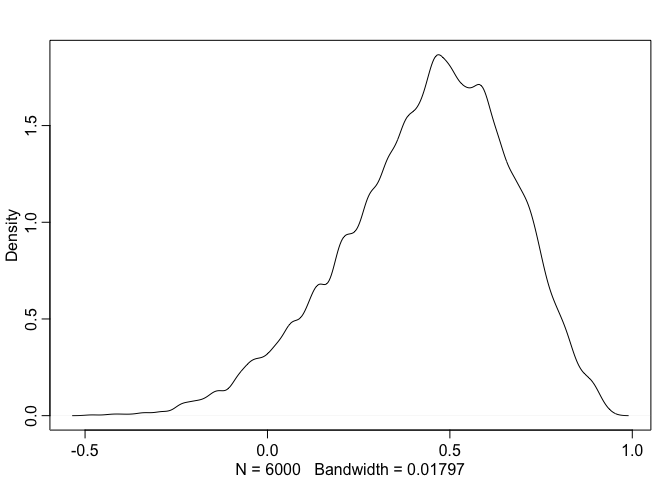

```r
post <- extract.samples(m13.m1)
dens( post$Rho[,1,2] )
```

```r
### these show a postive correlation rather than non between slope and intercept?

##intercept and slope
## morrining and afternoon wait time
## most traffic in
```

## 13M2. Fit this multilevel model to the simulated café data:

# μi = αcafé[i] + βcafé[i]Ai

# αcafé ∼ Normal(α, σα)

# βcafé ∼Normal(β,σβ)

# α ∼ Normal(0, 10)

# β ∼ Normal(0, 10)

# σ ∼ HalfCauchy(0, 1)

# σα ∼ HalfCauchy(0, 1) σβ ∼HalfCauchy(0,1)

## Use WAIC to compare this model to the model from the chapter, the one that uses a multi-variate Gaussian prior. Explain the result.

```r
m13.m2 <- map2stan(
    alist(
        wait ~ dnorm( mu , sigma ),
        mu <- a_cafe[cafe] + b_cafe[cafe]*afternoon,
        a_cafe[cafe] ~ dnorm(a, sigma_alpha),
        b_cafe[cafe] ~ dnorm(b, sigma_beta),
        a ~ dnorm(0,10),
        b ~ dnorm(0,10),
        sigma ~ dcauchy(0,1),
        sigma_alpha ~ dcauchy(0,1),
        sigma_beta ~ dcauchy(0,1)
),
data=d2 ,
iter=5000 , warmup=2000 , chains=2 )
```

[output not shown]

[output cut: 53 more lines]

[output not shown]

```
## Computing WAIC
```

```
## Constructing posterior predictions
```

[output not shown]

```r
compare(m13.m1,m13.m2)
```

```
##         WAIC pWAIC dWAIC weight    SE  dSE
## m13.m1 312.2  31.0   0.0   0.58 20.57   NA
## m13.m2 312.9  32.5   0.7   0.42 20.87 2.71
```

These models are pretty much the same, except I amd confused why the dcauchy vars differ…

## 13M3. Re-estimate the varying slopes model for the UCBadmit data, now using a non-centered pa- rameterization. Compare the eciency of the forms of the model, using n_eff. Which is better? Which chain sampled faster?

```r
library(rethinking)
data(UCBadmit)
d <- UCBadmit
d$male <- ifelse( d$applicant.gender=="male" , 1 , 0 )
d$dept_id <- coerce_index( d$dept )

m13.3 <- map2stan(
    alist(
        admit ~ dbinom( applications , p ),
        logit(p) <- a_dept[dept_id] +
                    bm_dept[dept_id]*male,
        c(a_dept,bm_dept)[dept_id] ~ dmvnorm2( c(a,bm) , sigma_dept , Rho ),
        a ~ dnorm(0,10),
        bm ~ dnorm(0,1),
        sigma_dept ~ dcauchy(0,2),
        Rho ~ dlkjcorr(2)
),
data=d , warmup=1000 , iter=5000 , chains=4 , cores=3 )
```

[output not shown]

[output cut: 8 more lines]

[output not shown]

```
##
## WARNING: No variance estimation is
##          performed for num_warmup < 20
##
##
## Chain 1, Iteration: 1 / 1 [100%]  (Sampling)
##  Elapsed Time: 4e-06 seconds (Warm-up)
##                0.000105 seconds (Sampling)
##                0.000109 seconds (Total)
```

```
## Computing WAIC
```

```
## Constructing posterior predictions
```

[output not shown]

```
## Aggregated binomial counts detected. Splitting to 0/1 outcome for WAIC calculation.
```

```r
m13.3NC <- map2stan(
    alist(
        admit ~ dbinom( applications , p ),
        logit(p) <- a + a_dept[dept_id] +
                    bm + bm_dept[dept_id]*male,
        c(a_dept,bm_dept)[dept_id] ~ dmvnormNC(sigma_dept , Rho ),
        a ~ dnorm(0,10),
        bm ~ dnorm(0,1),
        sigma_dept ~ dcauchy(0,2),
        Rho ~ dlkjcorr(2)
),
data=d , warmup=1000 , iter=5000 , chains=4 , cores=3 )
```

[output not shown]

[output cut: 17 more lines]

[output not shown]

```
## Computing WAIC
## Constructing posterior predictions
```

[output not shown]

```
## Aggregated binomial counts detected. Splitting to 0/1 outcome for WAIC calculation.
```

```r
#m13.3 There were 26 divergent iterations during sampling
#m13.3NC There were 4 divergent transitions after warmup
compare(m13.3, m13.3NC)
```

```
##           WAIC pWAIC dWAIC weight    SE  dSE
## m13.3   5190.9  11.0   0.0   0.53 57.27   NA
## m13.3NC 5191.1  10.8   0.2   0.47 57.16 0.88
```

```r
precis(m13.3, depth=2)
```

```
##                Mean StdDev lower 0.89 upper 0.89 n_eff Rhat
## bm_dept[1]    -0.79   0.27      -1.22      -0.36  4369    1
## bm_dept[2]    -0.21   0.33      -0.75       0.29  9260    1
## bm_dept[3]     0.08   0.14      -0.13       0.31 11554    1
## bm_dept[4]    -0.09   0.14      -0.32       0.13 12076    1
## bm_dept[5]     0.12   0.19      -0.18       0.41 11460    1
## bm_dept[6]    -0.12   0.27      -0.55       0.32 11271    1
## a_dept[1]      1.30   0.26       0.89       1.70  4545    1
## a_dept[2]      0.74   0.32       0.23       1.27  9368    1
## a_dept[3]     -0.65   0.08      -0.78      -0.51 13151    1
## a_dept[4]     -0.62   0.11      -0.78      -0.45 12889    1
## a_dept[5]     -1.13   0.11      -1.31      -0.95 11895    1
## a_dept[6]     -2.60   0.20      -2.92      -2.29 12816    1
## a             -0.51   0.73      -1.63       0.61  7467    1
## bm            -0.16   0.24      -0.53       0.20  7511    1
## sigma_dept[1]  1.67   0.63       0.84       2.47  8250    1
## sigma_dept[2]  0.50   0.26       0.15       0.84  6132    1
## Rho[1,1]       1.00   0.00       1.00       1.00 16000  NaN
## Rho[1,2]      -0.32   0.35      -0.89       0.19 11072    1
## Rho[2,1]      -0.32   0.35      -0.89       0.19 11072    1
## Rho[2,2]       1.00   0.00       1.00       1.00 14834    1
```

```r
precis(m13.3NC, depth=2)
```

```
##                   Mean StdDev lower 0.89 upper 0.89 n_eff Rhat
## z_N_dept_id[1,1]  1.27   0.56       0.37       2.15  4406    1
## z_N_dept_id[1,2]  0.88   0.51       0.07       1.69  4349    1
## z_N_dept_id[1,3]  0.00   0.40      -0.64       0.63  3963    1
## z_N_dept_id[1,4]  0.01   0.40      -0.66       0.61  4015    1
## z_N_dept_id[1,5] -0.33   0.42      -1.01       0.32  4107    1
## z_N_dept_id[1,6] -1.34   0.59      -2.24      -0.37  4886    1
## z_N_dept_id[2,1] -1.42   0.75      -2.62      -0.22  9437    1
## z_N_dept_id[2,2]  0.04   0.77      -1.16       1.28 12503    1
## z_N_dept_id[2,3]  0.33   0.47      -0.38       1.04  9684    1
## z_N_dept_id[2,4] -0.15   0.46      -0.86       0.59 11609    1
## z_N_dept_id[2,5]  0.33   0.56      -0.51       1.23 11616    1
## z_N_dept_id[2,6] -0.62   0.76      -1.85       0.55 10938    1
## L_Rho[1,1]        1.00   0.00       1.00       1.00 16000  NaN
## L_Rho[1,2]        0.00   0.00       0.00       0.00 16000  NaN
## L_Rho[2,1]       -0.31   0.35      -0.87       0.20  7565    1
## L_Rho[2,2]        0.87   0.14       0.68       1.00  7328    1
## a                -0.64   1.20      -2.52       1.29  6053    1
## bm               -0.02   1.00      -1.64       1.54  9980    1
## sigma_dept[1]     1.65   0.62       0.82       2.43  4738    1
## sigma_dept[2]     0.46   0.24       0.13       0.79  5288    1
## a_dept[1]         1.90   0.73       0.74       2.99  4136    1
## a_dept[2]         1.32   0.76       0.16       2.52  4282    1
## a_dept[3]         0.00   0.69      -1.03       1.05  3928    1
## a_dept[4]         0.03   0.69      -1.04       1.05  3996    1
## a_dept[5]        -0.49   0.69      -1.56       0.53  3948    1
## a_dept[6]        -1.97   0.69      -3.03      -0.90  4259    1
## bm_dept[1]       -0.72   0.28      -1.18      -0.28  8000    1
## bm_dept[2]       -0.13   0.30      -0.62       0.33 16000    1
## bm_dept[3]        0.10   0.13      -0.11       0.31 16000    1
## bm_dept[4]       -0.07   0.14      -0.29       0.15 16000    1
## bm_dept[5]        0.15   0.17      -0.14       0.42 16000    1
## bm_dept[6]       -0.07   0.26      -0.47       0.35 16000    1
## Rho[1,1]          1.00   0.00       1.00       1.00 16000  NaN
## Rho[1,2]         -0.31   0.35      -0.87       0.20  7565    1
## Rho[2,1]         -0.31   0.35      -0.87       0.20  7565    1
## Rho[2,2]          1.00   0.00       1.00       1.00 15315    1
```

## 13M4 Use WAIC to compare the Gaussian process model of Oceanic tools to the models fit to the same data in Chapter 10.

## Pay special attention to the effective numbers of parameters, as estimated by WAIC.

```r
library(rethinking)
data(islandsDistMatrix)
# display short column names, so fits on screen
Dmat <- islandsDistMatrix
colnames(Dmat) <- c("Ml","Ti","SC","Ya","Fi","Tr","Ch","Mn","To","Ha")
round(Dmat,1)
```

```
##             Ml  Ti  SC  Ya  Fi  Tr  Ch  Mn  To  Ha
## Malekula   0.0 0.5 0.6 4.4 1.2 2.0 3.2 2.8 1.9 5.7
## Tikopia    0.5 0.0 0.3 4.2 1.2 2.0 2.9 2.7 2.0 5.3
## Santa Cruz 0.6 0.3 0.0 3.9 1.6 1.7 2.6 2.4 2.3 5.4
## Yap        4.4 4.2 3.9 0.0 5.4 2.5 1.6 1.6 6.1 7.2
## Lau Fiji   1.2 1.2 1.6 5.4 0.0 3.2 4.0 3.9 0.8 4.9
## Trobriand  2.0 2.0 1.7 2.5 3.2 0.0 1.8 0.8 3.9 6.7
## Chuuk      3.2 2.9 2.6 1.6 4.0 1.8 0.0 1.2 4.8 5.8
## Manus      2.8 2.7 2.4 1.6 3.9 0.8 1.2 0.0 4.6 6.7
## Tonga      1.9 2.0 2.3 6.1 0.8 3.9 4.8 4.6 0.0 5.0
## Hawaii     5.7 5.3 5.4 7.2 4.9 6.7 5.8 6.7 5.0 0.0
```

```r
data(Kline2) # load the ordinary data, now with coordinates
d <- Kline2
d$society <- 1:10 # index observations


m13.7 <- map2stan(
    alist(
        total_tools ~ dpois(lambda),
        log(lambda) <- a + g[society] + bp*logpop,
        g[society] ~ GPL2( Dmat , etasq , rhosq , 0.01 ),
        a ~ dnorm(0,10),
        bp ~ dnorm(0,1),
        etasq ~ dcauchy(0,1),
        rhosq ~ dcauchy(0,1)
    ),
    data=list(
        total_tools=d$total_tools,
        logpop=d$logpop,
        society=d$society,
        Dmat=islandsDistMatrix),
    warmup=2000 , iter=1e4 , chains=4 )
```

[output not shown]

[output cut: 89 more lines]

[output not shown]

```
## Computing WAIC
```

```
## Constructing posterior predictions
```

[output not shown]

```r
d$log_pop <- log(d$population)
d$contact_high <- ifelse( d$contact=="high" , 1 , 0 )




m10.11 <- map(
    alist(
        total_tools ~ dpois( lambda ),
        log(lambda) <- a + bp*log_pop + bc*contact_high,
        a ~ dnorm(0,100),
        c(bp,bc) ~ dnorm( 0 , 1 )
), data=d )

compare(m10.11, m13.7,n=1e4)
```

```
##        WAIC pWAIC dWAIC weight    SE   dSE
## m13.7  67.3   4.0   0.0      1  2.16    NA
## m10.11 79.2   4.3  11.9      0 11.30 11.76
```

## 13H1. Let’s revisit the Bangladesh fertility data, data(bangladesh),from the practice problems for Chapter 12.

```r
data(bangladesh)
d <- bangladesh
head(d)
```

```
##   woman district use.contraception living.children age.centered urban
## 1     1        1                 0               4      18.4400     1
## 2     2        1                 0               1      -5.5599     1
## 3     3        1                 0               3       1.4400     1
## 4     4        1                 0               4       8.4400     1
## 5     5        1                 0               1     -13.5590     1
## 6     6        1                 0               1     -11.5600     1
```

```r
## clean up data
d$district_id <- as.integer(as.factor(d$district))
sort(unique(d$district_id))
```

```
##  [1]  1  2  3  4  5  6  7  8  9 10 11 12 13 14 15 16 17 18 19 20 21 22 23
## [24] 24 25 26 27 28 29 30 31 32 33 34 35 36 37 38 39 40 41 42 43 44 45 46
## [47] 47 48 49 50 51 52 53 54 55 56 57 58 59 60
```

```r
## Now there are 60 values, contiguous integers 1 to 60.

colnames(d) <- gsub("\\.", "_", colnames(d))
d$number_of_women_in_distict <- rep(1,1934)

head(d)
```

```
##   woman district use_contraception living_children age_centered urban
## 1     1        1                 0               4      18.4400     1
## 2     2        1                 0               1      -5.5599     1
## 3     3        1                 0               3       1.4400     1
## 4     4        1                 0               4       8.4400     1
## 5     5        1                 0               1     -13.5590     1
## 6     6        1                 0               1     -11.5600     1
##   district_id number_of_women_in_distict
## 1           1                          1
## 2           1                          1
## 3           1                          1
## 4           1                          1
## 5           1                          1
## 6           1                          1
```

## Fit a model with both varying intercepts by district_id and varying slopes of urban by district_id. You are still predicting use.contraception.

```r
m13.h1 <- map2stan(
    alist(
        use_contraception ~ dbinom( 1 , p ) ,
        logit(p) <- a_district[district_id] + b_district[district_id]*urban,
        c(a_district,b_district)[district_id] ~   dmvnorm2(c(a,b),sigma_dist,Rho),
        Rho ~ dlkjcorr(2),
        c(a,b) ~ dnorm(0,1) ,
        c(sigma,sigma_dist) ~ dcauchy(0,1)
    ), data=d , iter=4000 , chains=4)
```

[output not shown]

[output cut: 43 more lines]

[output not shown]

```
## The following numerical problems occured the indicated number of times on chain 2
```

[output not shown]

```
## When a numerical problem occurs, the Hamiltonian proposal gets rejected.
```

```
## See http://mc-stan.org/misc/warnings.html#exception-hamiltonian-proposal-rejected
```

```
## If the number in the 'count' column is small, do not ask about this message on stan-users.
```

[output not shown]

```
## The following numerical problems occured the indicated number of times on chain 3
```

[output not shown]

```
## When a numerical problem occurs, the Hamiltonian proposal gets rejected.
```

```
## See http://mc-stan.org/misc/warnings.html#exception-hamiltonian-proposal-rejected
```

```
## If the number in the 'count' column is small, do not ask about this message on stan-users.
```

[output not shown]

```
## Computing WAIC
```

```
## Constructing posterior predictions
```

[output not shown]

```r
precis(m13.h1, depth=2)
```

```
##                 Mean StdDev lower 0.89 upper 0.89 n_eff Rhat
## b_district[1]   1.07   0.39       0.45       1.71  8000    1
## b_district[2]   0.66   0.70      -0.42       1.81  8000    1
## b_district[3]   0.99   0.83      -0.31       2.30  8000    1
## b_district[4]   1.65   0.64       0.60       2.59  4015    1
## b_district[5]   0.64   0.62      -0.34       1.62  8000    1
## b_district[6]   1.33   0.55       0.45       2.19  8000    1
## b_district[7]   0.82   0.71      -0.36       1.91  8000    1
## b_district[8]   0.95   0.65      -0.08       1.96  8000    1
## b_district[9]   1.05   0.66       0.02       2.09  8000    1
## b_district[10]  1.24   0.78      -0.01       2.42  8000    1
## b_district[11]  1.66   0.84       0.40       3.01  3899    1
## b_district[12]  0.43   0.59      -0.50       1.37  8000    1
## b_district[13]  0.28   0.60      -0.66       1.22  8000    1
## b_district[14]  1.26   0.44       0.56       1.94  8000    1
## b_district[15]  0.47   0.61      -0.50       1.44  8000    1
## b_district[16]  0.61   0.67      -0.45       1.66  8000    1
## b_district[17]  0.82   0.69      -0.27       1.91  8000    1
## b_district[18]  0.89   0.51       0.10       1.72  8000    1
## b_district[19]  0.99   0.63      -0.06       1.91  8000    1
## b_district[20]  0.56   0.72      -0.55       1.73  8000    1
## b_district[21] -0.34   0.71      -1.43       0.79  4167    1
## b_district[22]  1.04   0.73      -0.17       2.12  8000    1
## b_district[23]  0.85   0.72      -0.29       1.97  8000    1
## b_district[24]  1.30   0.78       0.02       2.49  8000    1
## b_district[25]  0.20   0.45      -0.50       0.92  8000    1
## b_district[26]  0.60   0.73      -0.57       1.75  8000    1
## b_district[27]  1.18   0.61       0.24       2.15  8000    1
## b_district[28]  0.75   0.60      -0.26       1.65  8000    1
## b_district[29]  1.18   0.59       0.22       2.09  8000    1
## b_district[30]  1.05   0.48       0.25       1.77  8000    1
## b_district[31]  0.41   0.57      -0.48       1.34  8000    1
## b_district[32]  1.03   0.71      -0.09       2.16  8000    1
## b_district[33]  1.28   0.70       0.21       2.42  8000    1
## b_district[34] -0.71   0.64      -1.71       0.29  3654    1
## b_district[35]  0.46   0.47      -0.28       1.19  8000    1
## b_district[36]  0.51   0.66      -0.63       1.49  8000    1
## b_district[37]  0.29   0.74      -0.90       1.41  8000    1
## b_district[38]  1.29   0.68       0.25       2.38  8000    1
## b_district[39]  0.28   0.65      -0.71       1.33  8000    1
```

[output cut: 75 more lines]

```
## a_district[55] -0.13   0.34      -0.65       0.43  8000    1
## a_district[56] -1.19   0.38      -1.79      -0.57  8000    1
## a_district[57] -0.18   0.37      -0.78       0.40  8000    1
## a_district[58] -1.18   0.47      -1.93      -0.45  8000    1
## a_district[59] -1.16   0.39      -1.75      -0.52  8000    1
## a_district[60] -1.18   0.34      -1.75      -0.65  8000    1
## Rho[1,1]        1.00   0.00       1.00       1.00  8000  NaN
## Rho[1,2]       -0.65   0.16      -0.89      -0.42  1562    1
## Rho[2,1]       -0.65   0.16      -0.89      -0.42  1562    1
## Rho[2,2]        1.00   0.00       1.00       1.00  7494    1
## a              -0.70   0.10      -0.86      -0.54  5911    1
## b               0.69   0.17       0.42       0.95  4284    1
## sigma           0.31  12.40      -5.78       5.99  1058    1
## sigma_dist[1]   0.58   0.10       0.43       0.74  2454    1
## sigma_dist[2]   0.79   0.20       0.47       1.10  1272    1
```